# Liste Rouge Régionale des poissons d’eau douce de Bretagne

Analyses bivariées des indicateurs régionaux - Mann-Kendall et Sen-Theil

OFB Bretagne

2024-08-13

# 1 Objectif : Dynamique de population des poissons d’eau douce de Bretagne

Script : 13_mann_kendall_sen_theil

Ce script a pour objectif de réaliser les tests de Mann-Kendall suivis des régressions de Sen-Theil sur les indicateurs régionaux.

Le test de Mann-Kendall est efficace pour traiter les tendances non linéaires, et ne nécessite pas de distributions normales (Yue & Wang, 2004). Cette dernière analyse est exécutée, outre sur les données agrégées à l‘échelle régionale, sur les indicateurs annuels relatifs aux points de prélèvements.

# 2 Installation

## 2.1 Chargement des packages, fonctions et des données

```r
library(ggthemes) # Chargement des packages
library(tidyverse)
library(trend)
library(ggh4x)
library(sf)
library(gt)
library(COGiter)
```

```r
load(file = "../processed_data/calcul_indicateurs_regionaux.rda") # Chargement des données
load(file = "../processed_data/analyse_indicateurs_regionaux_pour_mk_glm.rda")
load(file = "../processed_data/selection_pop_ope.rda")
load(file = "../processed_data/pre_traitements_donnees_env.rda")
load(file = "../processed_data/assemblage_tab_par_ope.rda")
load(file = "../processed_data/analyse_selection_especes.rda")
load(file = "../processed_data/selection_pop_ope_carte.rda")
```

```r
source(file = "../R/mk_st_by_group.R") # Fonction développée par Pascal Irz
source(file = "../R/mann_kendall_sen.R") # Fonction développée par Pascal Irz
source(file = "../R/mk_st_multi_periodes.R") #Fonction développée par Léa Bouchet
source(file = "../R/calcul_taux_evolution.R")
```

```r
mes_especes <- c("ANG","BRO", "CHA", "CHE","PER", "GAR", "GOU", "LOF", "LPP","SAT", "TRF", "VAI", "VAR")
```

# 3 Analyses bivariées : tests de Mann-Kendall / Sen-Theil

## 3.1 Introduction

Le test de tendance de Mann-Kendall est utilisé pour déterminer si une tendance existe dans les données issues des séries chronologiques. Il s’agit d’un test non paramétrique, ce qui signifie qu’il n’y a pas d’hypothèse sous-jacente concernant la normalité des données. Il s’agit d’un test d’hypothèses et les deux hypothèses sont les suivantes :

1. Ho (Accepté) : Il n’y a pas de tendance dans les données (valeur p>0,05).
2. Ha (Rejeté) : Une tendance est présente dans les données

## 3.2 Application régionale

Nous souhaitons le faire pour plusieurs périodes (création de la fonction *mk_st_multi_periodes*). Nous sélectionnons les périodes à étudier (en variable de la fonction) :

```r
reg_indicateur_reduit <- reg_indicateur_reduit %>%
  filter(indicateur %in% c("densite_surface","taux_occurrence","pourcentage_juveniles"),
         stade == "ind")

periodes <- list(c(1990, 2023), # Création d'un objet contenant les périodes d'études
                 c(2005, 2023),
                 c(2008, 2023),
                 c(2011, 2023),
                 c(2013, 2023))
```

Nous exécutons la fonction *mk_st_multi_periodes* qui permet de calculer les différents test de Mann-Kendall et regressions de Sen-Theil pour les différentes périodes indiquées ci-avant.

```r
# Appeler la fonction pour calculer les résultats pour chaque période
reg_indicateur_lrr_tendances_mk_st <- mk_st_multi_periodes(df = reg_indicateur_reduit,
                                                              periods = periodes,
                                                              valeur = "valeur",
                                                              annee = "annee",
                                                              esp_code_alternatif = "esp_code_alternatif",
                                                              indicateur = "indicateur",
                                                              stade = "stade")


reg_indicateur_lrr_tendances_mk_st <- bind_rows(reg_indicateur_lrr_tendances_mk_st, # Concaténer tous les résultats en un seul dataframe final
                                                .id = "periode")

reg_indicateur_lrr_tendances_mk_st <- reg_indicateur_lrr_tendances_mk_st %>% # Filtrer les données selon les critères spécifiés
  filter((esp_code_alternatif == "ANG" & periode == "1990-2023") |
    (esp_code_alternatif %in% c("CHE", "LPP") & periode == "2005-2023") |
    (esp_code_alternatif %in% c("BRO", "LOF") & periode == "2008-2023") |
    (esp_code_alternatif %in% c("VAR", "GAR", "VAI", "PER") & periode == "2011-2023") |
    (esp_code_alternatif %in% c("SAT", "GOU", "TRF", "CHA") & periode == "2013-2023"))
```

## 3.3 Synthèse des premiers résultats

Toujours par soucis de lisibilité, seul les 3 indicateurs retenus apparaîtrons dans ce tableau final. Dans notre étude, les valeurs de densités surfaciques, le pourcentage de juvéniles et le taux d’occurrence semblent être les 3 données les plus informatives sur les tendances des populations de poissons d’eau douce de Bretagne. Ces informations sont alors synthétisées dans un tableau : les flèches vers le haut indiquent une croissance et celle vers le bas une décroissance de l’indicateur pour l’espèce considérée.

```r
# Définir des palettes de couleurs harmonieuses
tendance_palette <- c("\U2198" = "#88B04B", # rouge doux pour les tendances descendantes
                      "\U2197" = "red") # vert doux pour les tendances montantes

significativite_palette <- c(" " = "#D3D3D3",    # gris clair pour non significatif
                             "*" = "#FFC107",  # jaune pour p < 0.05
                             "**" = "#92D050", # orange pour p < 0.01
                             "***" = "#007844") # violet pour p < 0.001

tab_reg_indicateur_lrr_tendances_mk_st <- reg_indicateur_lrr_tendances_mk_st %>%
  select(esp_code_alternatif,
         periode,
         indicateur,
         trend,
         sig) %>%
  arrange(esp_code_alternatif,
          indicateur) %>%
  gt() %>%
  # Ajouter un titre et un sous-titre
  tab_header(title = md("**Synthèse des tendances des indicateurs des populations de poissons d'eau douce de Bretagne**"),subtitle = "Analyse des tendances régionales pour les périodes spécifiées") %>%
  cols_label(esp_code_alternatif = "Code Espèce",  # Renommer les colonnes
    periode = "Période d'Étude",
    indicateur = "Indicateur",
    trend = "Tendance",
    sig = "Significativité") %>%
  data_color(columns = trend,colors = tendance_palette) %>%
  data_color(columns = sig, colors = significativite_palette) %>%
  cols_align(align = "center",# Ajuster la taille de la police et l'alignement
    columns = c(esp_code_alternatif, periode, indicateur, trend, sig))

tab_reg_indicateur_lrr_tendances_mk_st # Affichage du tableau
```

**Synthèse des tendances des indicateurs des populations de poissons d’eau douce de Bretagne**

Analyse des tendances régionales pour les périodes spécifiées

| Code Espèce | Période d'Étude | Indicateur | Tendance | Significativité |
| --- | --- | --- | --- | --- |
| ANG | 1990-2023 | densite_surface | ↘ | *** |
| ANG | 1990-2023 | pourcentage_juveniles | ↗ | *** |
| ANG | 1990-2023 | taux_occurrence | ↘ | *** |
| BRO | 2008-2023 | densite_surface | ↘ |  |
| BRO | 2008-2023 | pourcentage_juveniles | . |  |
| BRO | 2008-2023 | taux_occurrence | ↘ |  |
| CHA | 2013-2023 | densite_surface | ↘ |  |
| CHA | 2013-2023 | pourcentage_juveniles | ↗ |  |
| CHA | 2013-2023 | taux_occurrence | ↗ |  |
| CHE | 2005-2023 | densite_surface | ↗ |  |
| CHE | 2005-2023 | pourcentage_juveniles | ↗ | ** |
| CHE | 2005-2023 | taux_occurrence | ↘ | * |
| GAR | 2011-2023 | densite_surface | ↗ | * |
| GAR | 2011-2023 | pourcentage_juveniles | ↗ |  |
| GAR | 2011-2023 | taux_occurrence | ↘ | ** |
| GOU | 2013-2023 | densite_surface | ↗ |  |
| GOU | 2013-2023 | pourcentage_juveniles | ↘ |  |
| GOU | 2013-2023 | taux_occurrence | ↗ |  |
| LOF | 2008-2023 | densite_surface | ↗ |  |
| LOF | 2008-2023 | pourcentage_juveniles | ↗ |  |
| LOF | 2008-2023 | taux_occurrence | ↘ |  |
| LPP | 2005-2023 | densite_surface | ↗ |  |
| LPP | 2005-2023 | pourcentage_juveniles | ↗ |  |
| LPP | 2005-2023 | taux_occurrence | ↗ | ** |
| PER | 2011-2023 | densite_surface | ↗ |  |
| PER | 2011-2023 | pourcentage_juveniles | ↘ |  |
| PER | 2011-2023 | taux_occurrence | ↗ |  |
| SAT | 2013-2023 | densite_surface | ↘ |  |
| SAT | 2013-2023 | pourcentage_juveniles | . |  |
| SAT | 2013-2023 | taux_occurrence | ↘ |  |
| TRF | 2013-2023 | densite_surface | ↗ |  |
| TRF | 2013-2023 | pourcentage_juveniles | ↘ | * |
| TRF | 2013-2023 | taux_occurrence | ↘ |  |
| VAI | 2011-2023 | densite_surface | ↗ |  |
| VAI | 2011-2023 | pourcentage_juveniles | ↘ |  |
| VAI | 2011-2023 | taux_occurrence | ↗ |  |
| VAR | 2011-2023 | densite_surface | ↘ |  |
| VAR | 2011-2023 | pourcentage_juveniles | . |  |
| VAR | 2011-2023 | taux_occurrence | ↘ |  |

# 4 Pré-traitement aux analyses spatiales des tendances temporelles

Afin d’obtenir une exploration plus fine des dynamiques, les tendances temporelles des densités surfaciques sont représentées spatialement à l’échelle des stations, à la fois pour la période d’étude (cf objet *periode*) et sur l’ensemble de la chronologie disponible (1990-2023).

## 4.1 Distribution des espèces

Nous souhaitons calculé la significativité des tendances à l’échelle des points de prélèvements avec le test mk_st. Dans un premier temps, un dataframe regroupant toutes les données relatives aux points de prélèvements est construit.

```r
ope_densite <- ope_indicateur %>%
  filter(esp_code_alternatif %in% mes_especes,
         indicateur == "densite_surface",
         stade == "ind") # Nous avons 7475 observations (sans les absences)

ope_esp_densite <- ope_densite %>% # df regroupant toutes mes opérations
  select(-esp_code_alternatif, -valeur) %>%
  distinct()

# Création d'un dataframe avec toutes les combinaisons possibles d'années, indicateurs, stades et esp_code_alternatif
combinaisons_ope_densite <- expand.grid(esp_code_alternatif = unique(ope_densite$esp_code_alternatif),
                                    ope_id = unique(ope_densite$ope_id))

ope_densite_complet <- ope_esp_densite %>%
  left_join(y = combinaisons_ope_densite) %>%
  left_join(y = ope_densite) %>%
  mutate(valeur = ifelse(is.na(valeur), 0, valeur)) # Nous avons maintenant 13663 observations (avec les absences : 1051 opérations * 13 espèces)
```

```r
ope_densite_periode_lrr <- ope_densite_complet %>% # Filtrage périodes d'étude de la Liste Rouge Régionale
  filter((esp_code_alternatif == "ANG" & annee >= 1990) |
      (esp_code_alternatif %in% c("CHE", "LPP") & annee >= 2005) |
      (esp_code_alternatif %in% c("BRO", "LOF", "VAR") & annee >= 2008) |
      (esp_code_alternatif %in% c("GAR", "VAI", "PER") & annee >= 2011) |
      (esp_code_alternatif %in% c("SAT", "GOU", "TRF", "CHA") & annee >= 2013))
```

## 4.2 Préparation des données géographiques (carte de fond)

```r
mes_depts <- departements_metro_geo %>%
  filter(DEP %in% c("22", "29", "35", "56", "53", "44", "50", "49")) %>%
  st_transform(crs = 4326) %>%
  st_crop(
    xmin = -5,
    xmax = -0.9,
    ymin = 47.4,
    ymax = 49
  )
```

# 5 Analyse spatiale des tendances temporelles - période LRR

Calcul des tendances par points de prélèvements sur la période d’étude LRR : application de la fonction *mk_st_by_group* :

```r
ope_densite_tendances_mk_st_lrr <- mk_st_by_group(ope_densite_periode_lrr,
                                                   valeur,
                                                   annee,
                                                   esp_code_alternatif,
                                                   indicateur,
                                                   stade,
                                                   pop_id)
```

## 5.1 Représentation graphique

```r
ope_densite_code_periode_lrr <- ope_densite_periode_lrr %>%
  select(esp_code_alternatif,
         pop_id) %>%
  distinct()

ope_densite_code_comple_periode_lrr <- ope_densite_periode_lrr %>%
  left_join(ope_densite_tendances_mk_st_lrr)
```

```r
carte_tendance_lrr <- ggplot(sta_id_ope_selection %>%
                               left_join(ope_densite_code_comple_periode_lrr,
                                         by = "pop_id") %>%
                               filter(!is.na(tendance))) +
  geom_sf(data = mes_depts, fill = "white", color = "black") +
  geom_sf(data = buffer, fill = NA, color = "grey") +
  geom_sf(aes(shape = tendance,
              fill = ifelse(tendance == "Non significative",
                            ifelse(sens_slope > 0, "Positif", "Négatif"), tendance),
              size = factor(ifelse(tendance == "Non significative", 1, 2))),
          stroke = 0.2) +
  scale_fill_manual(name = "Tendance",
    values = c("Diminution" = "red","Augmentation" = "darkgreen","Non significative" = "gray",
      "Positif" = "#92D050","Négatif" = "#FF6F6F")) +
  scale_shape_manual(name = "Tendance",
    values = c("Diminution" = 22, # carré plein
      "Augmentation" = 24, # triangle plein
      "Non significative" = 21)) + # cercle plein
  scale_size_manual(values = c("1" = 2, "2" = 4), guide = 'none') +
  facet_wrap(~ esp_code_alternatif) +
  theme(panel.background = element_rect(fill = "lightblue"),
    legend.position = "bottom",
    legend.key = element_rect(fill = NA),
    axis.text.x = element_text(size = 8, angle = 45, hjust = 0.5),
    plot.margin = unit(c(1, 1, 1, 1), "cm"))
  ggtitle("Tendances temporelles des densités par espèces à l'échelle des points de prélèvement - période LRR ")
```

```
## $title
## [1] "Tendances temporelles des densités par espèces à l'échelle des points de prélèvement - période LRR "
##
## attr(,"class")
## [1] "labels"
```

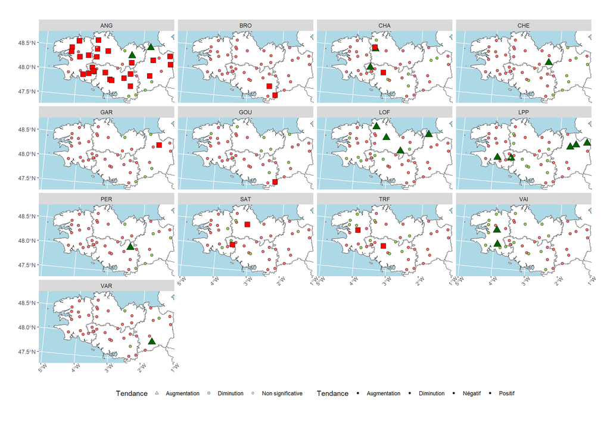

```r
carte_tendance_lrr <- carte_tendance_lrr + coord_sf(xlim = c(-5, -1.2), ylim = c(47.45, 48.8), default_crs = 4326)

carte_tendance_lrr
```

Enregistrement de la carte des tendances démographiques : Tendances temporelles des densités surfaciques par espèce à l’échelle des stations sur les périodes d’étude LRR (correspondant à la méthodologie UICN):

```r
ggsave(filename = "../assets/carte_tendances_sta_lrr.png",
       plot = carte_tendance_lrr, width = 10, height = 8, dpi = 300) # Enregistrer l'image
```

# 6 Analyse spatiale des tendances temporelles - période globale (1990-2023)

```r
ope_densite_tendances_mk_st_globale <- mk_st_by_group(ope_densite_complet,
                                                      valeur,
                                                      annee,
                                                      esp_code_alternatif,
                                                      indicateur,
                                                      stade,
                                                      pop_id)
```

## 6.1 Représentation graphique

Nous ne voulons faire apparaitre que les points de prélèvements où les espèces ont déjà été présentes :

```r
ope_densite_code <- ope_densite %>%
  select(esp_code_alternatif,
         pop_id) %>%
  distinct()

ope_densite_code_complet <- ope_densite_code %>%
  left_join(ope_densite_tendances_mk_st_globale)
```

Nous représentons une carte régionale avec les tendances démographiques des espèces propres aux stations (où les espèces ont été présentes au moins une fois) - sur la période globale de l’étude.

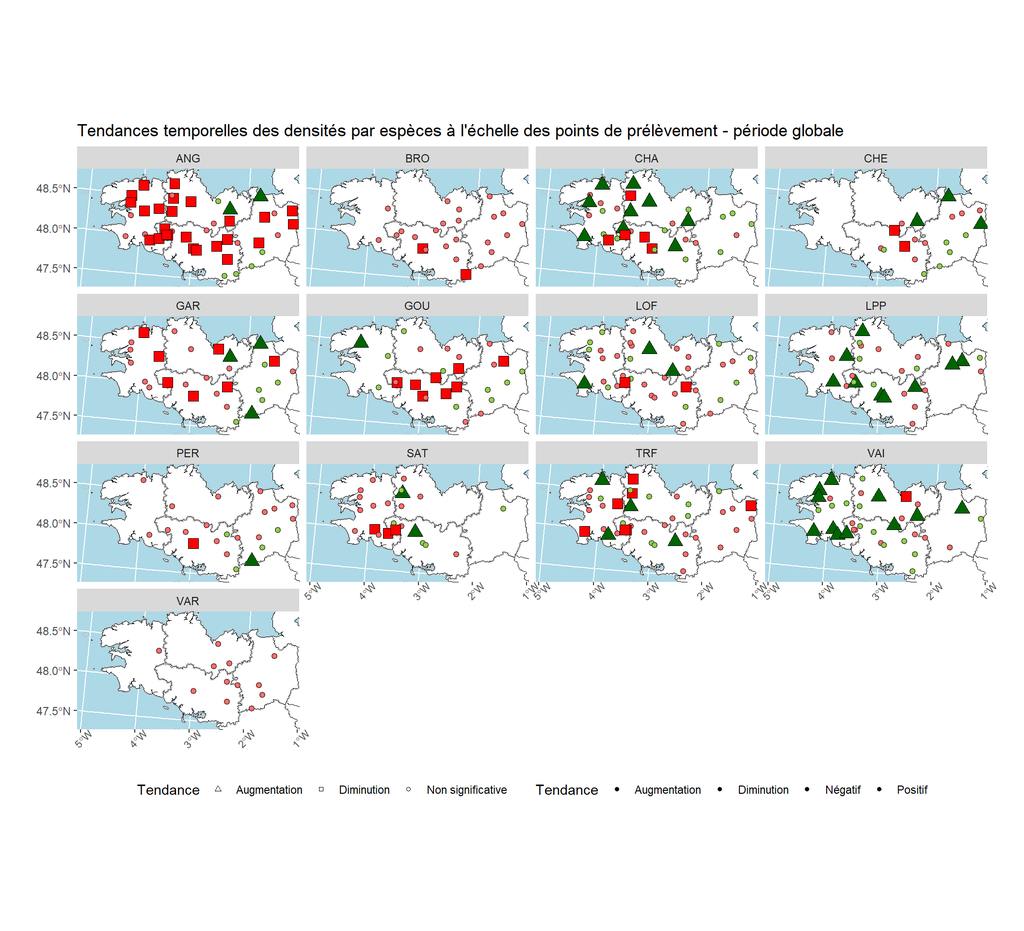

```r
carte_sta_facet_globale <- ggplot(sta_id_ope_selection %>%
                            left_join(ope_densite_code_complet, by = "pop_id")) +
  geom_sf(data = mes_depts, fill = "white", color = "black") +
  geom_sf(data = buffer, fill = NA, color = "grey") +
  geom_sf(aes(shape = tendance,
              fill = ifelse(tendance == "Non significative",
                            ifelse(sens_slope > 0, "Positif", "Négatif"), tendance),
              size = factor(ifelse(tendance == "Non significative", 1, 2))),
          stroke = 0.2) +
  scale_fill_manual(name = "Tendance",
                    values = c("Diminution" = "red","Augmentation" = "darkgreen",
                               "Non significative" = "gray","Positif" = "#92D050",
                               "Négatif" = "#FF6F6F")) +
  scale_shape_manual(name = "Tendance",
    values = c("Diminution" = 22, # carré plein
      "Augmentation" = 24, # triangle plein
      "Non significative"= 21)) + # cercle plein
  scale_size_manual(values = c("1" = 2, "2" = 4), guide = 'none') +
  facet_wrap(~ esp_code_alternatif) +
  theme(panel.background = element_rect(fill = "lightblue"),
    legend.position = "bottom",
    legend.key = element_rect(fill = NA),
    axis.text.x = element_text(size = 8, angle = 45, hjust = 0.5),
    plot.margin = unit(c(1, 1, 1, 1), "cm")) +
  ggtitle("Tendances temporelles des densités par espèces à l'échelle des points de prélèvement - période globale ")

carte_sta_facet_globale <- carte_sta_facet_globale + coord_sf(xlim = c(-5, -1.2), ylim = c(47.45, 48.8), default_crs = 4326)

carte_sta_facet_globale
```

Enregistrement de la carte des tendances démographiques : Tendances temporelles des densités surfaciques par espèce à l’échelle des stations sur les périodes d’étude globale (correspondant ici aux années 1990-2023):

```r
ggsave(filename = "../assets/carte_tendances_sta_globale.png",
       plot = carte_sta_facet_globale, width = 10, height = 8, dpi = 300) # Enregistrer l'image
```

# 7 Sauvegarde

Nous sauvegardons dans un fichier .rda les jeux de données relatifs aux tests de Mann-Kendall qui nous servira pour des analyses futures.

```r
save(reg_indicateur_lrr_tendances_mk_st,
     reg_indicateur_lrr_tendances_lm,
     tab_reg_indicateur_lrr_tendances_mk_st,
     tab_reg_indicateur_lrr_tendances_lm,
     file = "../processed_data/lm_mann_kendall_tendances.rda")
```

# 8 Références bibliographiques

Irz, P., Mondy, C., Richard, B. Bonnafoux, L. (2024). aspe: An R package to analyse and visualise river fish data in France. R package version 0.4.1, https://github.com/PascalIrz/aspe/

Kendall, M. G. (1975). Rank correlation methods. London: Griffin. Knouft JH, Ficklin DL. 2017. The potential impacts of climate change on biodiversity in flowing freshwater systems. Annual Review of Ecology, Evolution, and Systematics 48, 111–133.

Mann, H.B. (1945). Nonparametric tests against trend. Econometrica 13, 1-245.

Sen, P. K. (1968). Estimates of the regression coefficient based on Kendall’s Tau. Journal of the American Statistical Association 63, 1379–1389.

Theil, H. (1950). A rank-invariant method of linear and polynomial regression analysis. Indagationes Mathematicae 1 (2), 14 p.